# Lab 8

Rahmat Ashari

Mar 11, 2020

# Task 1

```r
getwd()
```

```
## [1] "C:/Users/ra/Documents/StatClass/Lab 8"
```

# Task 2

**Sampling from uniform distribution between 0 and 5 with 10 samples**

```r
uni = runif(10,0,5)
uni
```

```
##  [1] 4.86098894 1.03068988 4.11499287 0.03849757 4.30001590 0.52168292
##  [7] 4.24071487 1.88320290 4.78897902 0.08784913
```

Population mean

```r
0.5*(5+0)
```

```
## [1] 2.5
```

Population variance

```r
(5-0)^2/12
```

```
## [1] 2.083333
```

Mean and Std Dev of the sample

```r
meanS = mean(uni)
stdS = sd(uni)

meanS
```

```
## [1] 2.586761
```

```r
stdS
```

```
## [1] 2.053379
```

**Samples sum and mean**

Statistics for $\overline{y}$
$$\overline{y} \sim N(\mu, \frac{\sigma^2}{n})$$

For a normal distribution,

$$\mu = \frac{a+b}{n} = \frac{0+5}{2} = 2.5$$
$$\sigma^2 = \frac{1}{n}\frac{(b-a)^2}{12} = \frac{1}{10}\frac{(5-0)^2}{12} = 0.2083$$
Hence,

$$\overline{y} \sim N(2.5, 0.2083)$$

Statistics for T

$$T \sim N(n\mu, n\sigma^2)$$
$$T \sim N(10*2.5, 10*2.083)$$
$$T \sim N(25, 20.83)$$

**Simulating Central Limit Theorem from a Uniform Distribution**

Distribution of sample sum

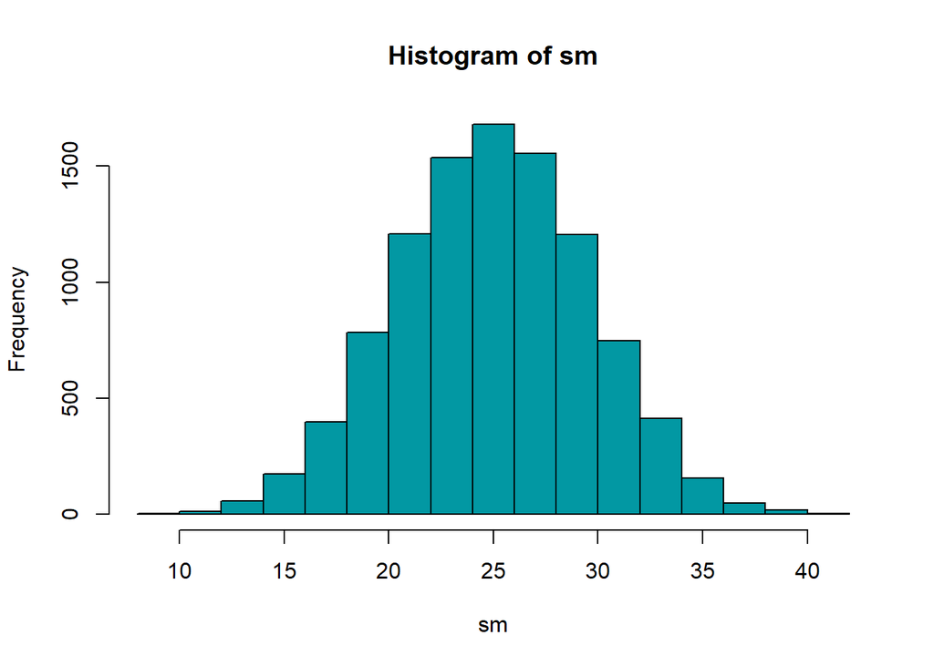

```r
myclt=function(n,iter){
  y=runif(n*iter,0,5) # A
  data=matrix(y,nr=n,nc=iter,byrow=TRUE) #B
  sm=apply(data,2,sum) #C
  hist(sm, c =  '#0298A3')
  sm
}

w = myclt(n=10,iter=10000) #D
```

Code explanation:

> A: Take n number of samples from a uniform distribution with x between 0 and 5 by iteration number of times.

> B: Store the samples of each iteration, column represents iteration

> C: take the sum by column

> D: Execute the function with 10 samples and 10,000 iterations

```r
#mean of w
mean(w)
```

```
## [1] 24.96893
```

```r
#variance of w
sd(w)^2
```

```
## [1] 21.06048
```

Distribution of sample mean

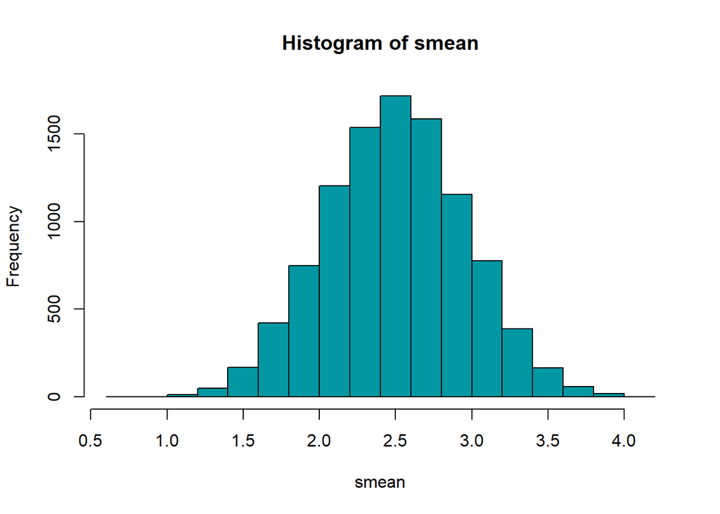

```r
myclt2=function(n,iter){
  y=runif(n*iter,0,5)
  data=matrix(y,nr=n,nc=iter,byrow=TRUE)
  smean=apply(data,2,mean)
  hist(smean, c = '#0298A3')
  smean
}

w2 = myclt2(n=10,iter=10000)
```

```r
#mean of w2
mean(w2)
```

```
## [1] 2.498954
```

```r
#variance of w2
sd(w2)^2
```

```
## [1] 0.2087605
```

# Task 3

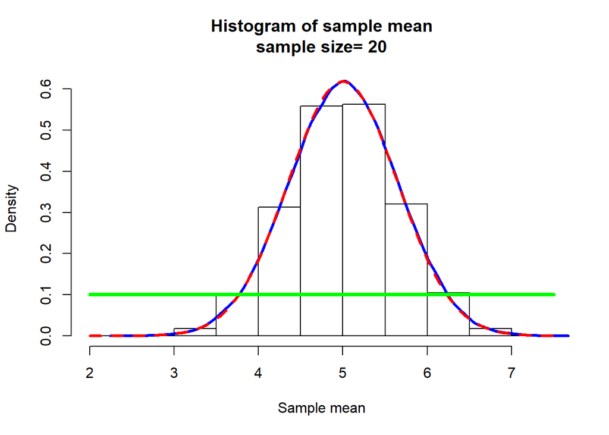

```r
mycltu=function(n,iter,a=0,b=10){
  y=runif(n*iter,a,b)
  data=matrix(y,nr=n,nc=iter,byrow=TRUE)
  w=apply(data,2,mean)
  param=hist(w,plot=FALSE)
  ymax=max(param$density)
  ymax=1.1*ymax
  hist(w,freq=FALSE,  ylim=c(0,ymax), main=paste("Histogram of sample mean",
"\n", "sample size= ",n,sep=""),xlab="Sample mean")
  lines(density(w),col="Blue",lwd=3)
  curve(dnorm(x,mean=(a+b)/2,sd=(b-a)/(sqrt(12*n))),add=TRUE,col="Red",lty=2,lwd=3)
  curve(dunif(x,a,b),add=TRUE,lwd=4, col = 'green')

}
mycltu(n=20,iter=100000)
```

**Explanation to Some of the Code Lines**

`w=apply(data,2,mean)` The apply function uses 2 as the second input because we want to get the mean of each column -that represents iteration- in the matrix *data*

`mycltu(n=20,iter=100000)` will give 2,000,000 terms: 20 samples for each iteration, totaling 100,000 iterations.

The part `dnorm(x,mean=(a+b)/2,sd=(b-a)/(sqrt(12*n))), ...)` is actually similar to creating normal distribution as previous labs. Nonetheless, here we are using the statistics of a uniform distribution. The mean is trivial. For the standard deviation however, we know the variance is expressed as $\frac{(b-a)^2}{12}$ and we know standard deviation is the square root of the variance. This is why the standard deviation in the function is expressed as such.

```r
n.list = c(1,2,3,5,10,30)

for (i in n.list){

  mycltu(n=i,iter=100000)

}
```

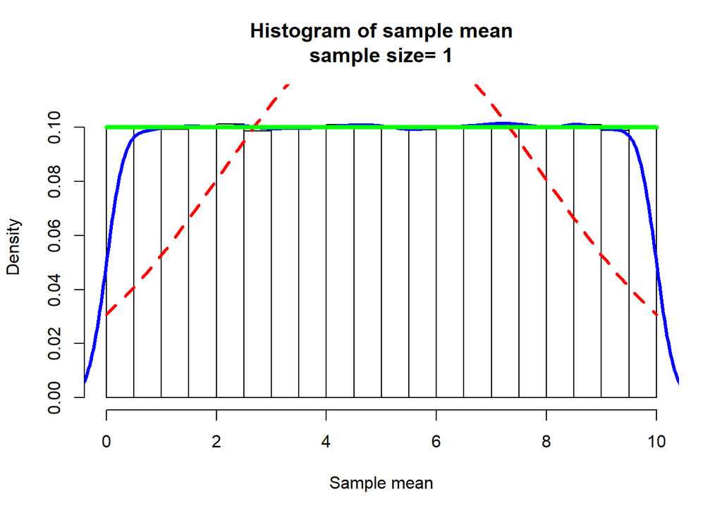

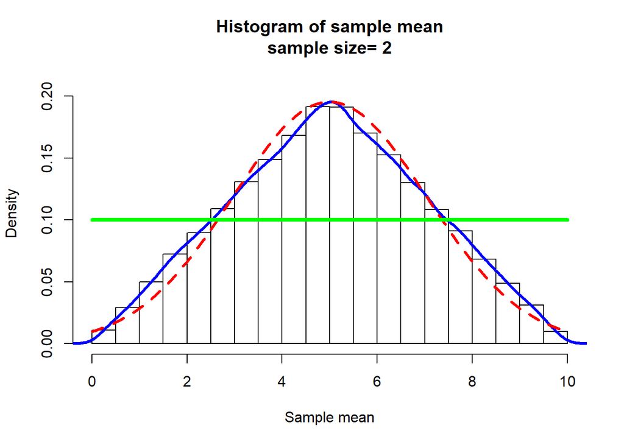

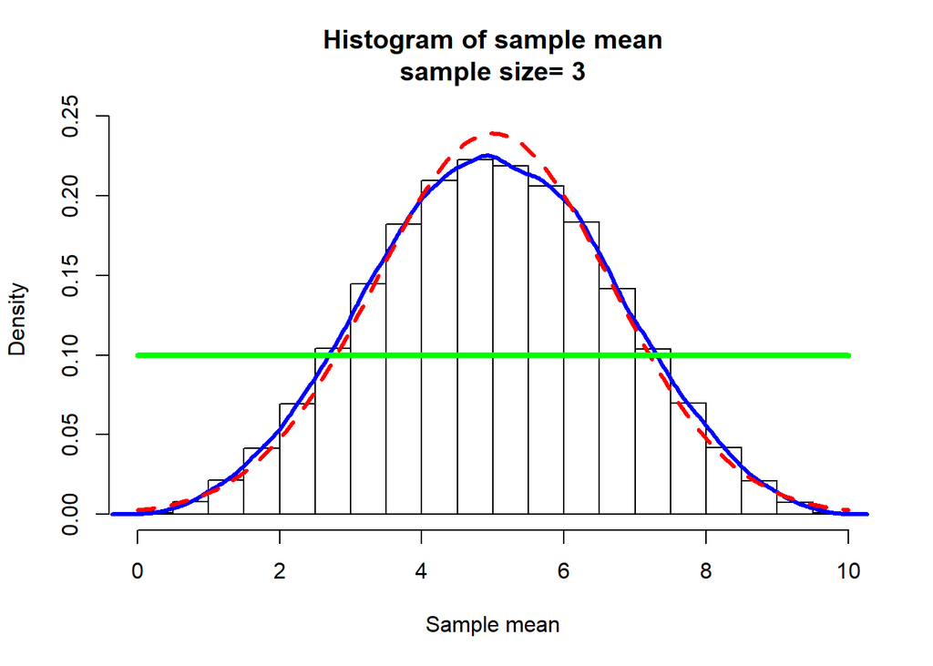

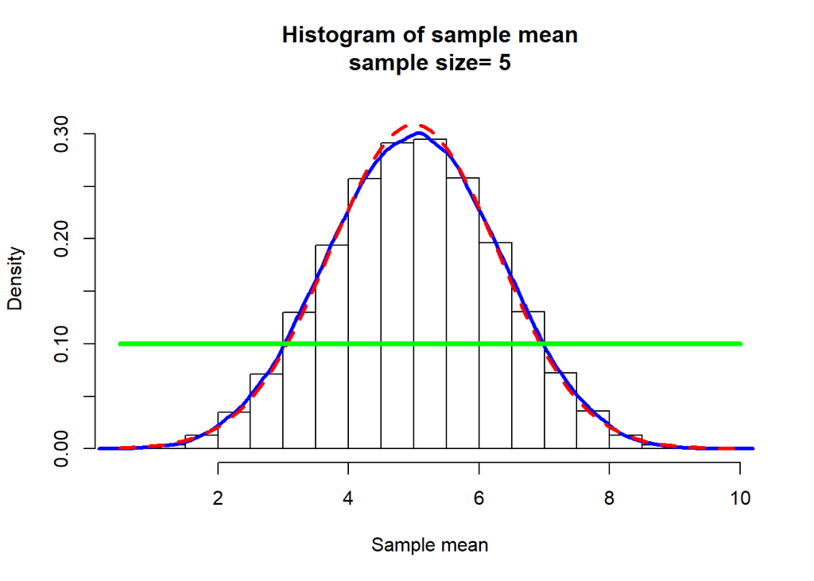

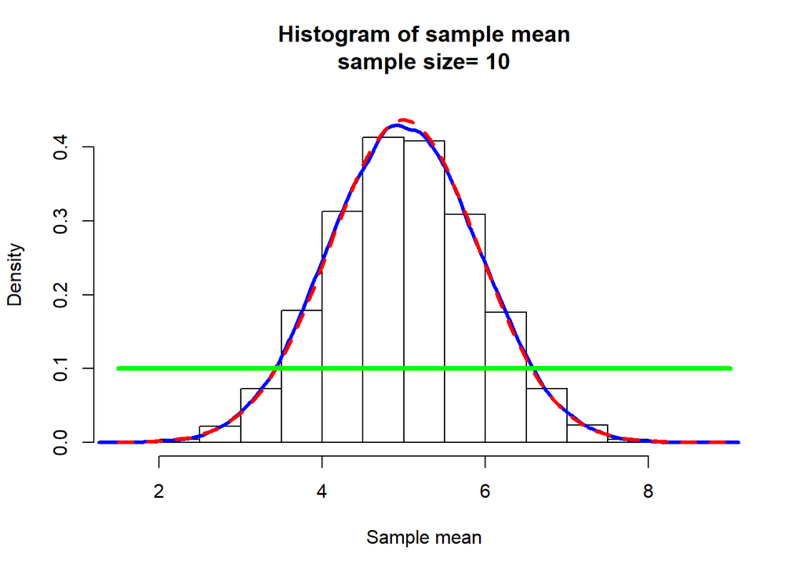

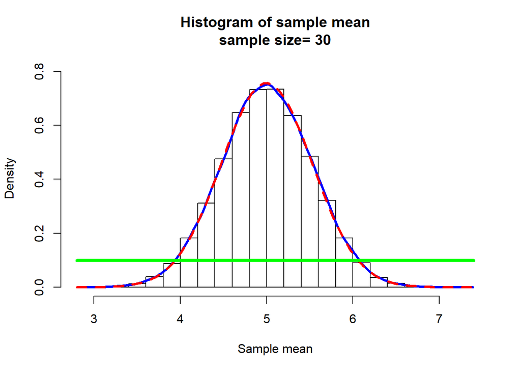

It is observed that one sample will simply give you a uniform distribution. Two samples will yield a somewhat triangular distribution. The distribution is becoming more Gaussian as the number of samples increases.

# Task 4

```r
mycltb=function(n,iter,p=0.5,...){

  y=rbinom(n*iter,size=n,prob=p)
  data=matrix(y,nr=n,nc=iter,byrow=TRUE)
  w=apply(data,2,mean)
  param=hist(w,plot=FALSE)
  ymax=max(param$density)
  ymax=1.1*ymax
  hist(w,freq=FALSE,  ylim=c(0,ymax),
  main=paste("Histogram of sample mean","\n", "sample size= ",n,sep=""),
  xlab="Sample mean",...)
  lines(density(w),col="Blue",lwd=3)
  curve(dnorm(x,mean=n*p,sd=sqrt(p*(1-p))),add=TRUE,col="Red",lty=2,lwd=3)

}
```

**For p = 0.3**

```r
n4.list = c(1,2,3,5,10,30)

for (i in n4.list){
  mycltb(n=i,iter=10000,p=0.3)
}
```

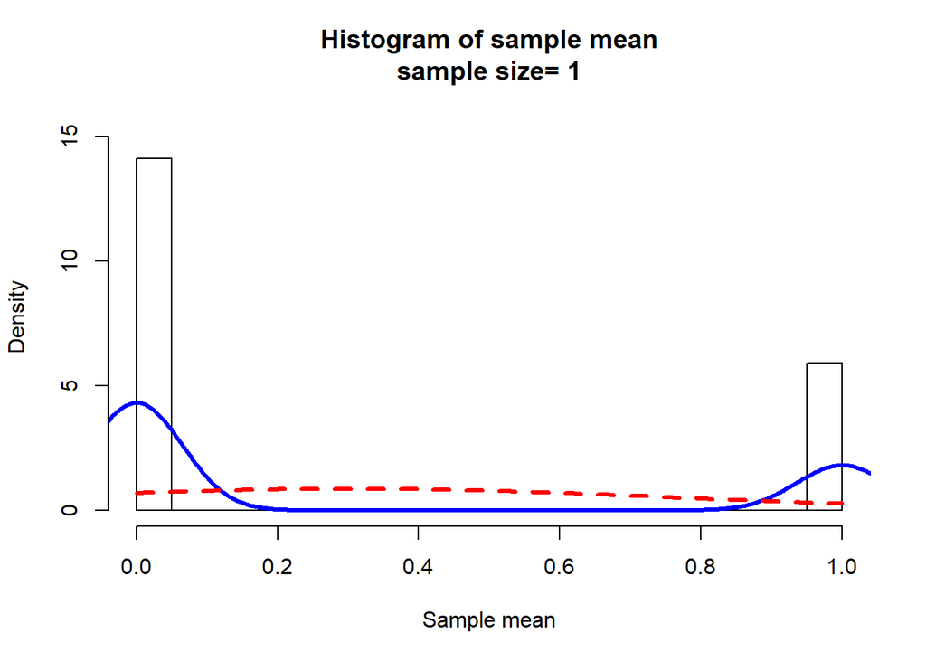

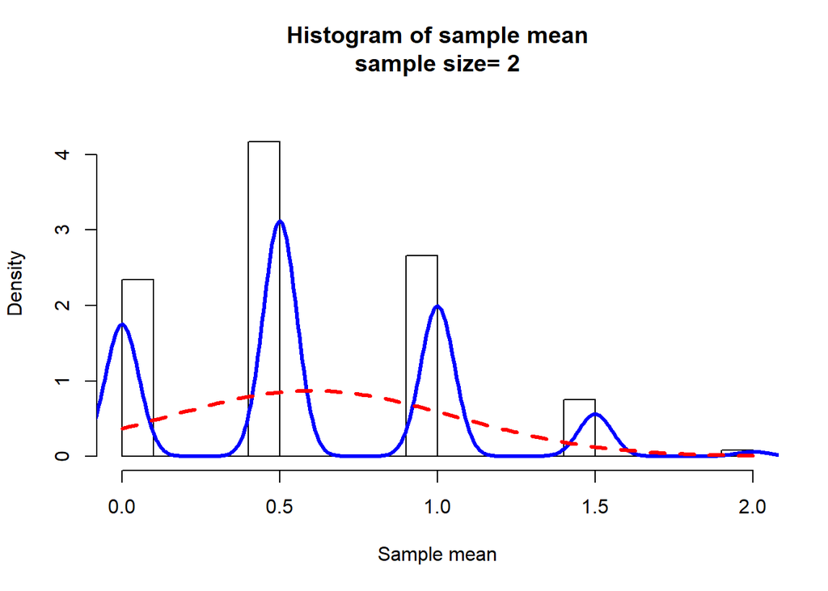

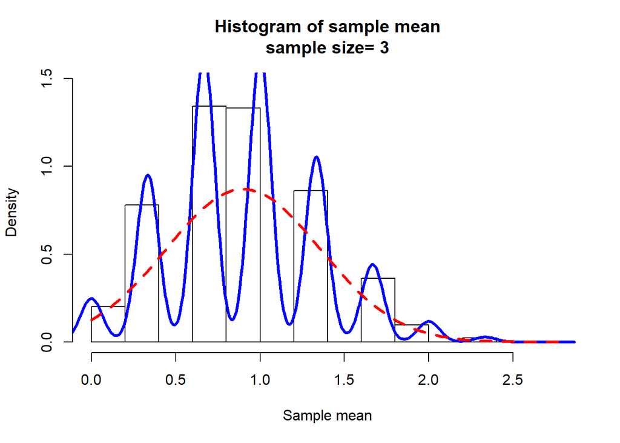

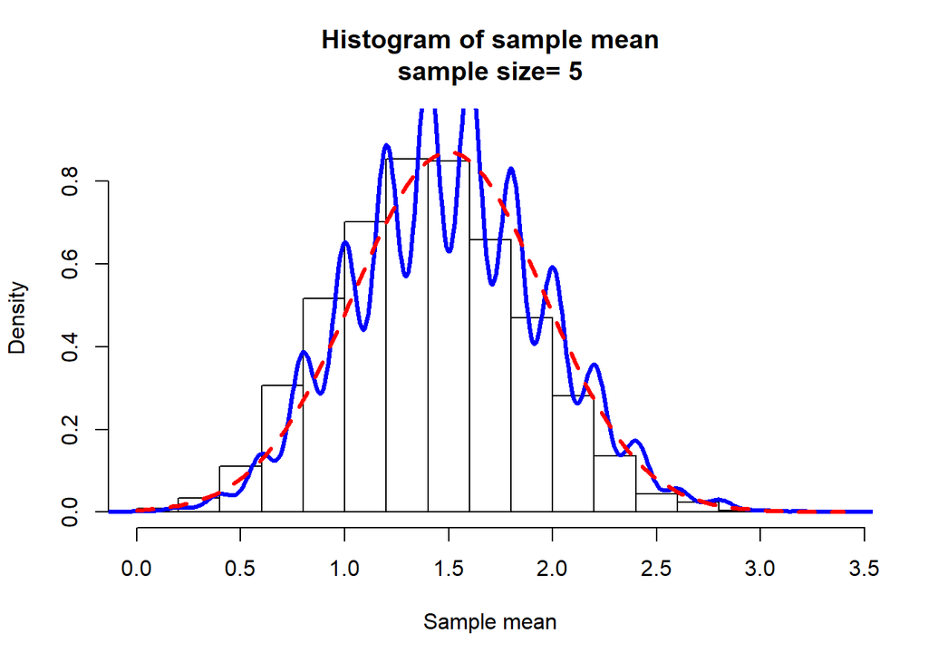

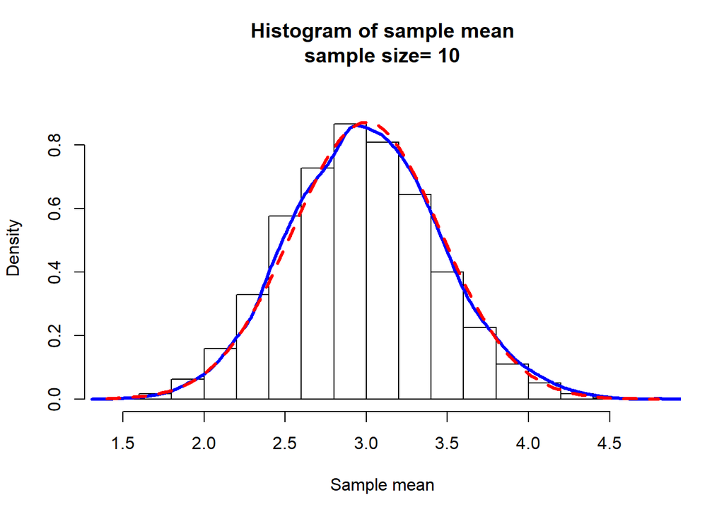

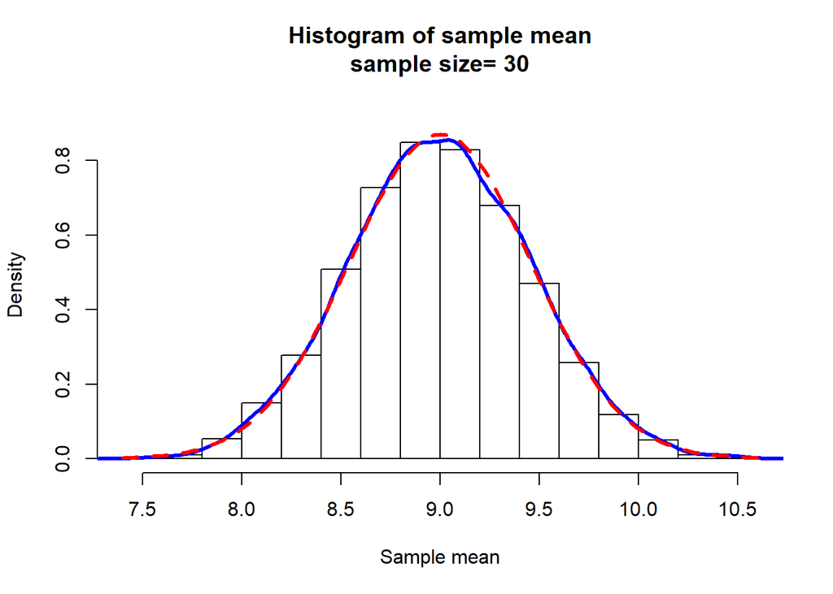

**for p = 0.7**

```r
for (i in n4.list){
  mycltb(n=i,iter=10000,p=0.7)
}
```

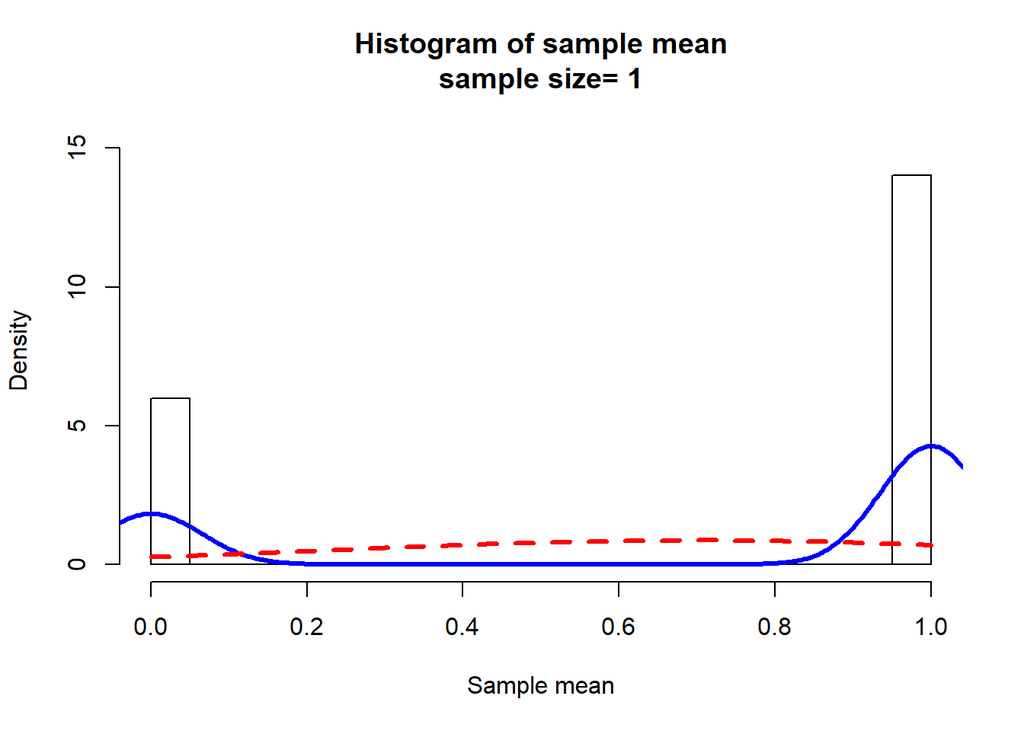

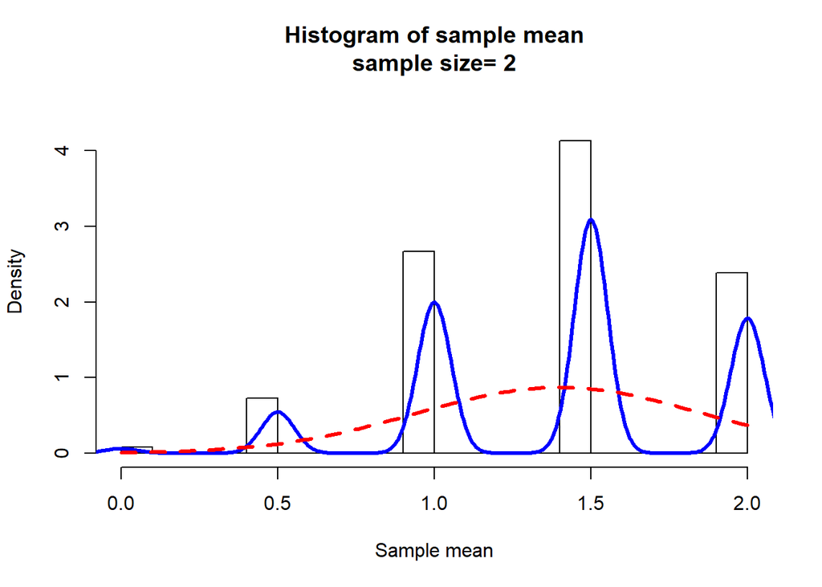

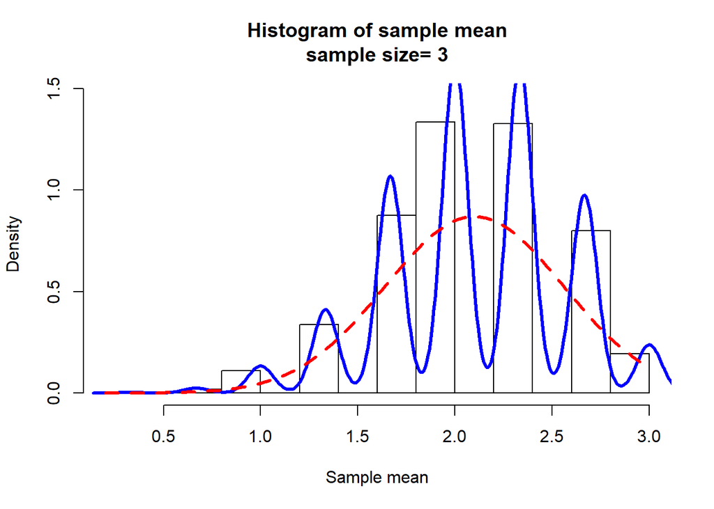

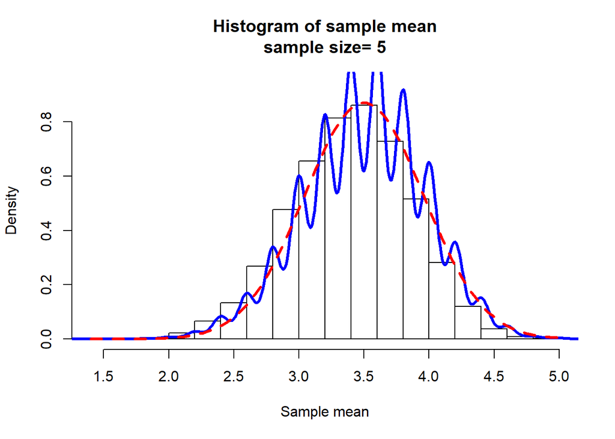

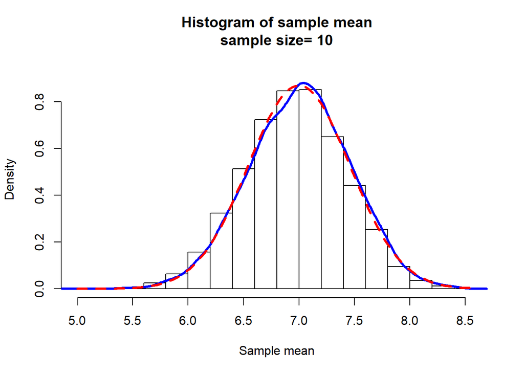

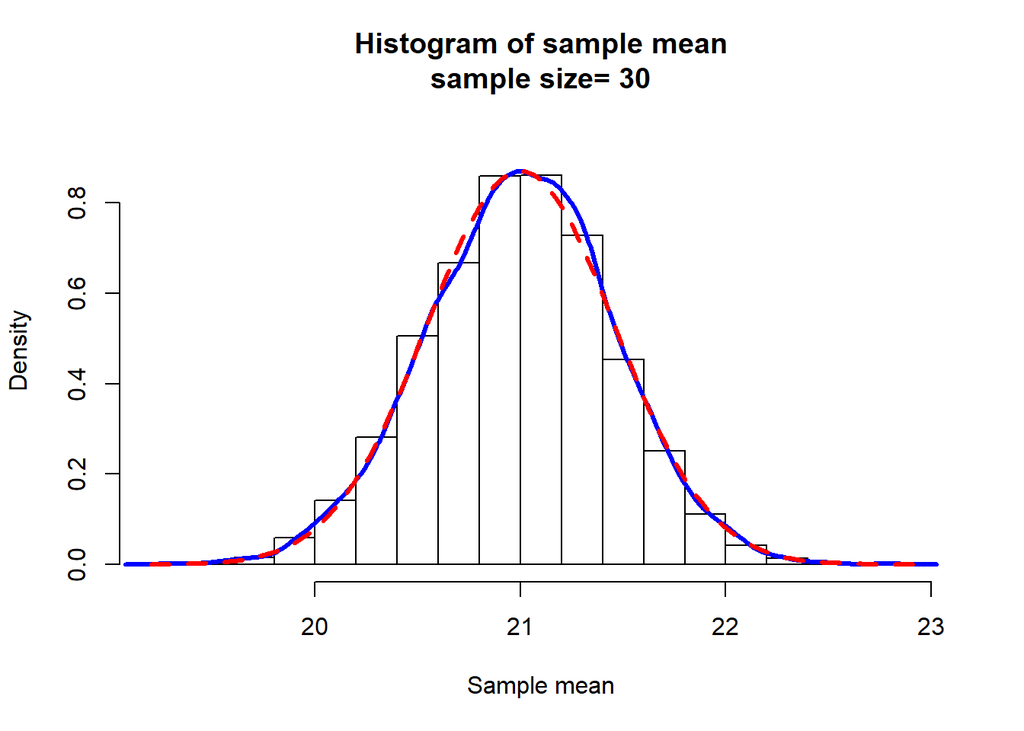

**For p = 0.5**

```r
for (i in n4.list){
  mycltb(n=i,iter=10000,p=0.5)
}
```

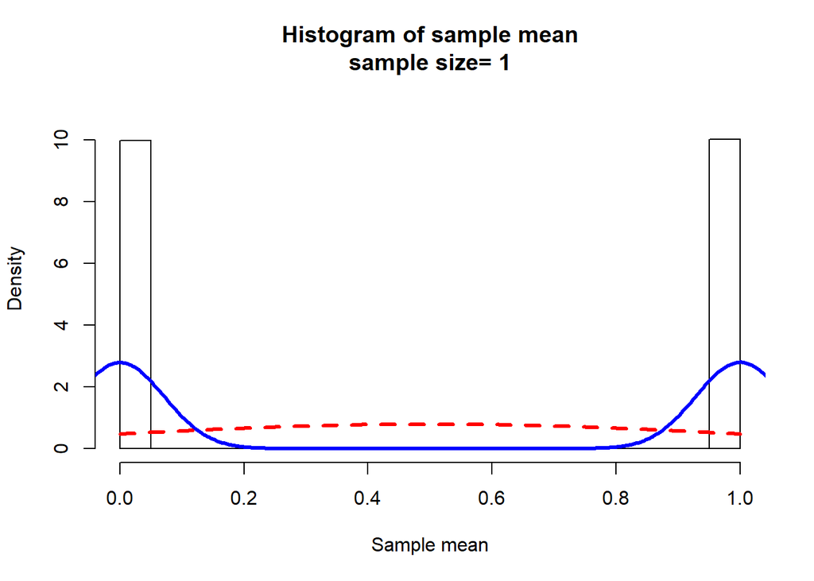

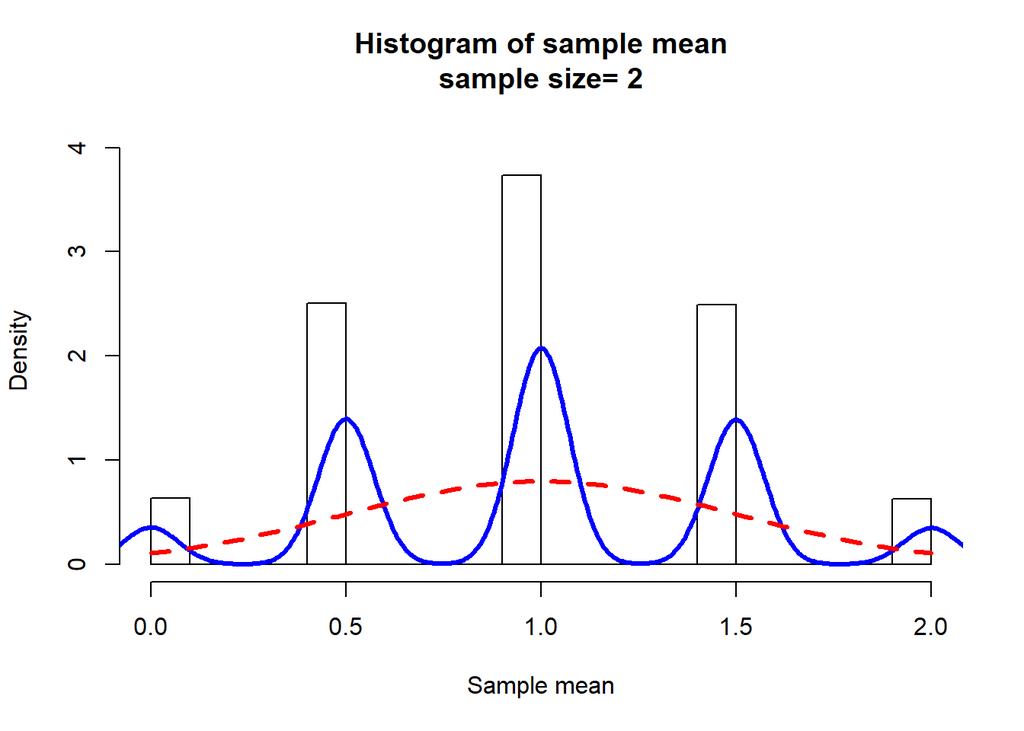

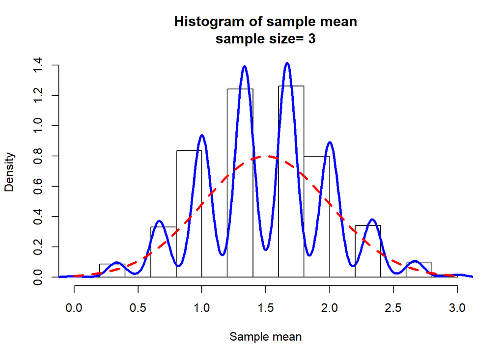

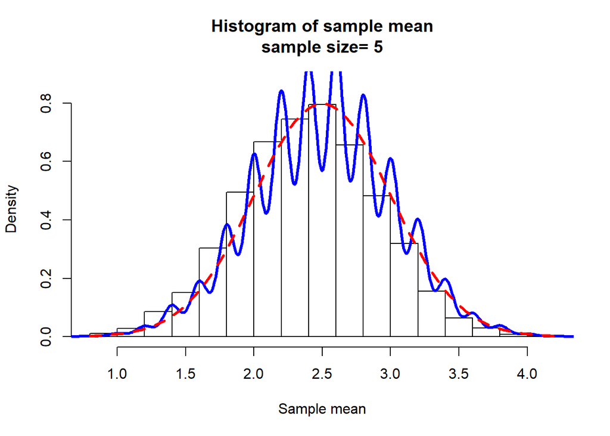

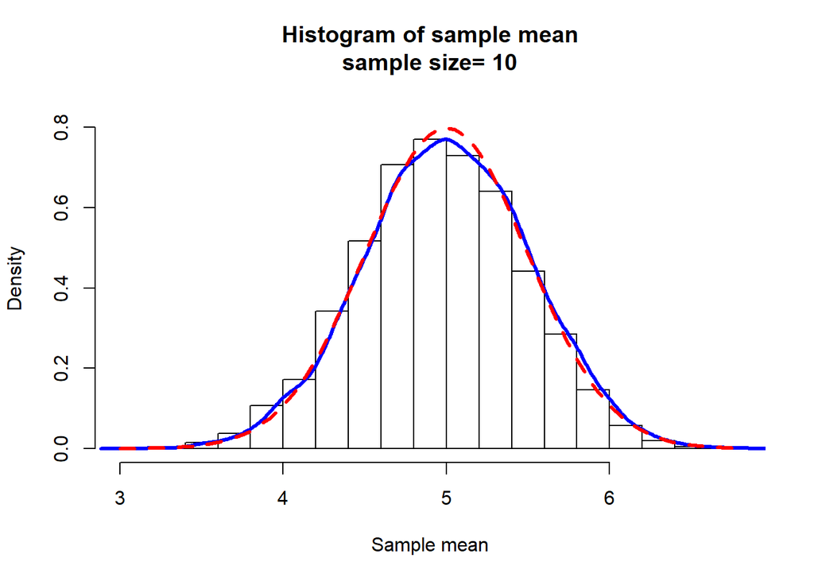

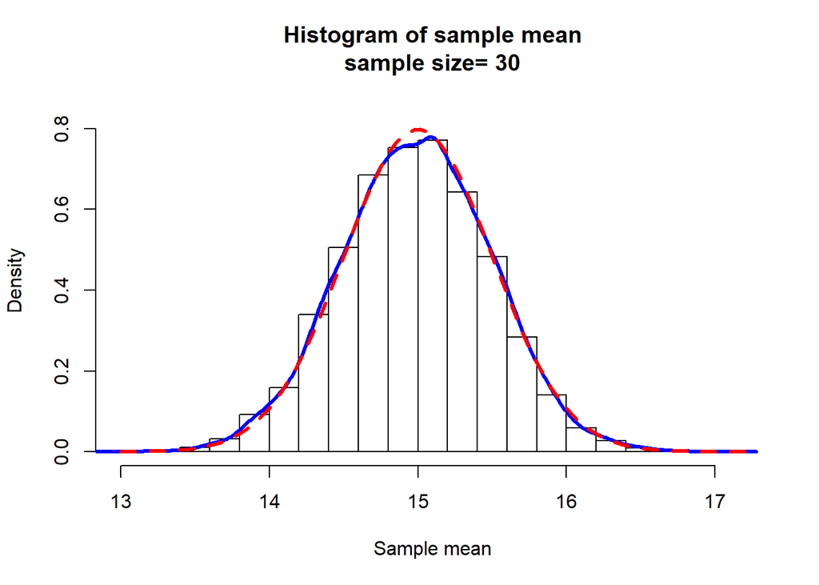

For all values of p, distribution becomes more Gaussian with increasing sample size. The mean is *np*.

# Task 5

```r
mycltp=function(n,iter,lambda=10,...){

  y=rpois(n*iter,lambda=lambda)
  data=matrix(y,nr=n,nc=iter,byrow=TRUE)
  w=apply(data,2,mean)
  param=hist(w,plot=FALSE)
  ymax=max(param$density)
  ymax=1.1*ymax
  layout(matrix(c(1,1,2,3),nr=2,nc=2, byrow=TRUE))
  hist(w,freq=FALSE,  ylim=c(0,ymax), col=rainbow(max(w)),
  main=paste("Histogram of sample mean","\n", "sample size= ",n," iter=",iter," lambda=",lambda,sep=""),
xlab="Sample mean",...)
  curve(dnorm(x,mean=lambda,sd=sqrt(lambda/n)),add=TRUE,col="Red",lty=2,lwd=3) # add a theoretical curve
  barplot(table(y)/(n*iter),col=rainbow(max(y)), main="Barplot of sampled y", ylab ="Rel. Freq",xlab="y" )
  x=0:max(y)
  plot(x,dpois(x,lambda=lambda),type="h",lwd=5,col=rainbow(max(y)),
  main="Probability function for Poisson", ylab="Probability",xlab="y")

}
```

**For lambda = 4, iter = 10,000**

```r
n5.list = c(2,3,5,10,20)

for (i in n5.list){
  mycltp(n=i,iter=10000, lambda = 4)
}
```

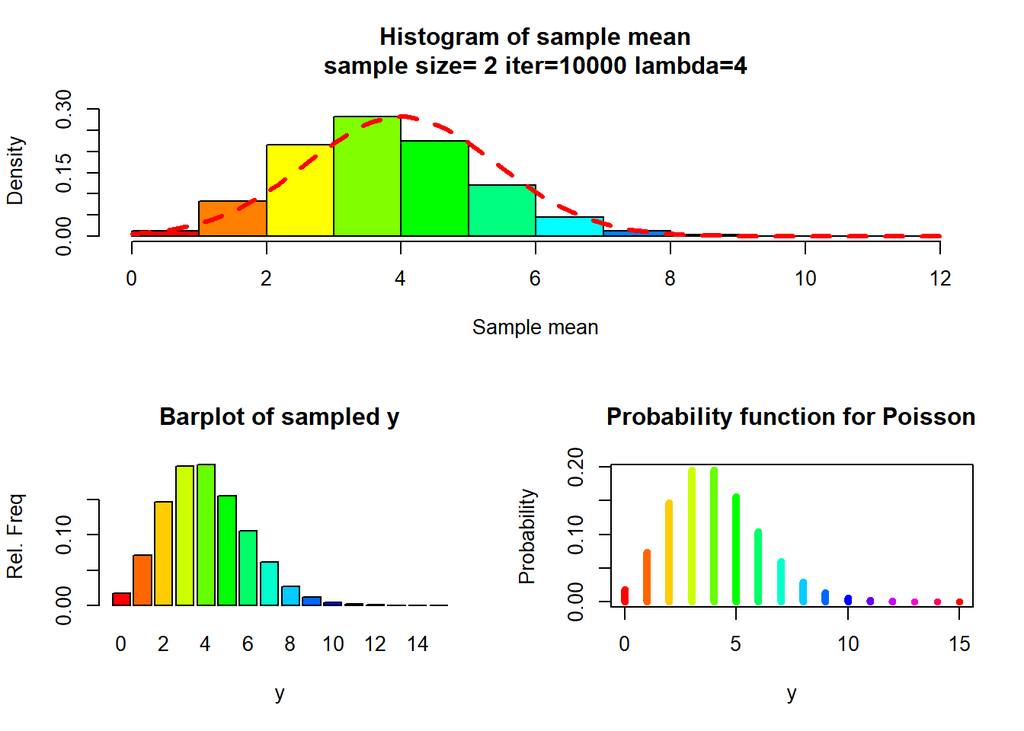

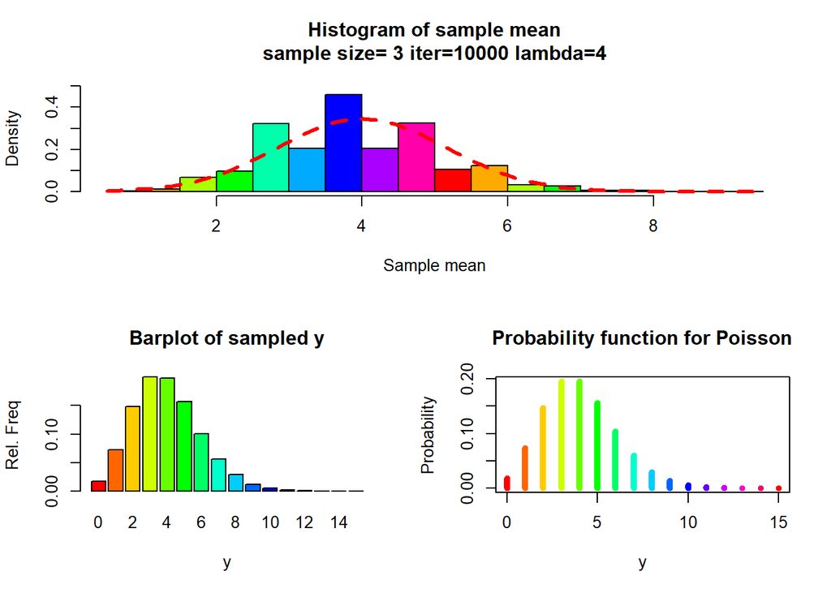

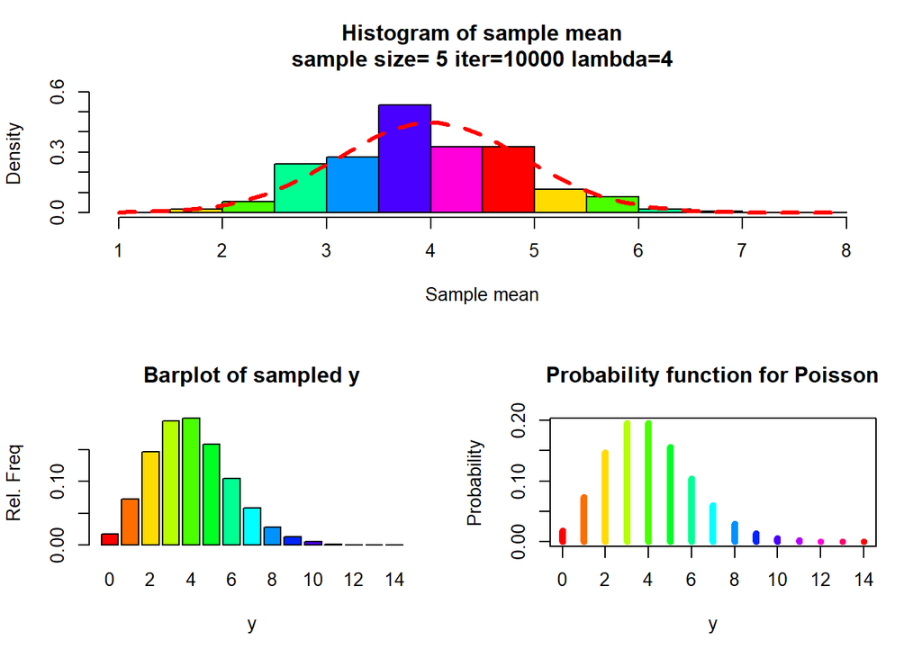

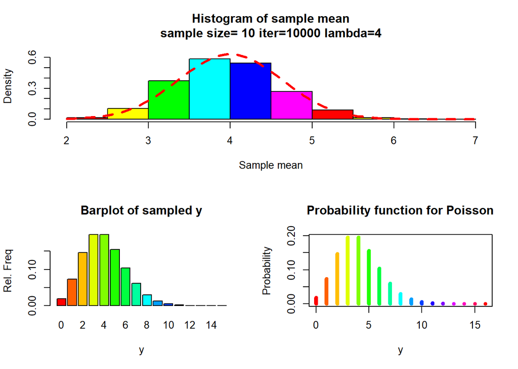

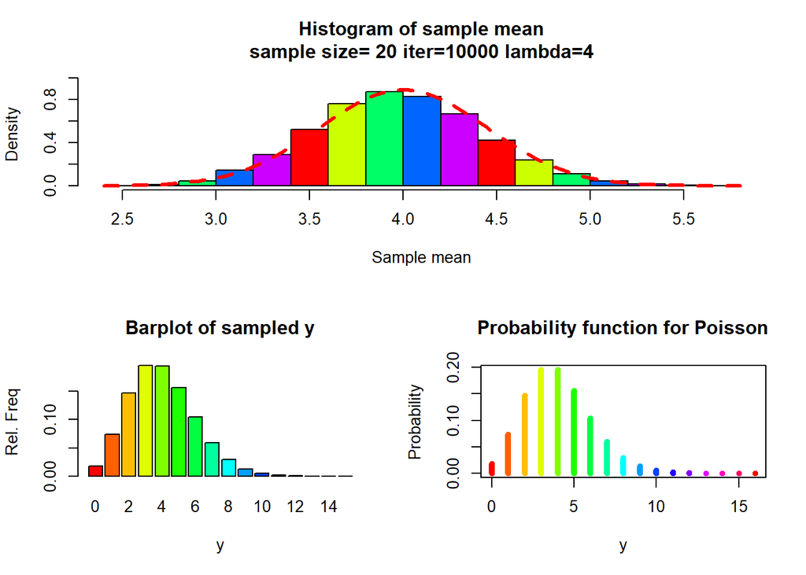

**For lambda = 10, iter = 10,000**

```r
for (i in n5.list){
  mycltp(n=i,iter=10000, lambda = 10)
}
```

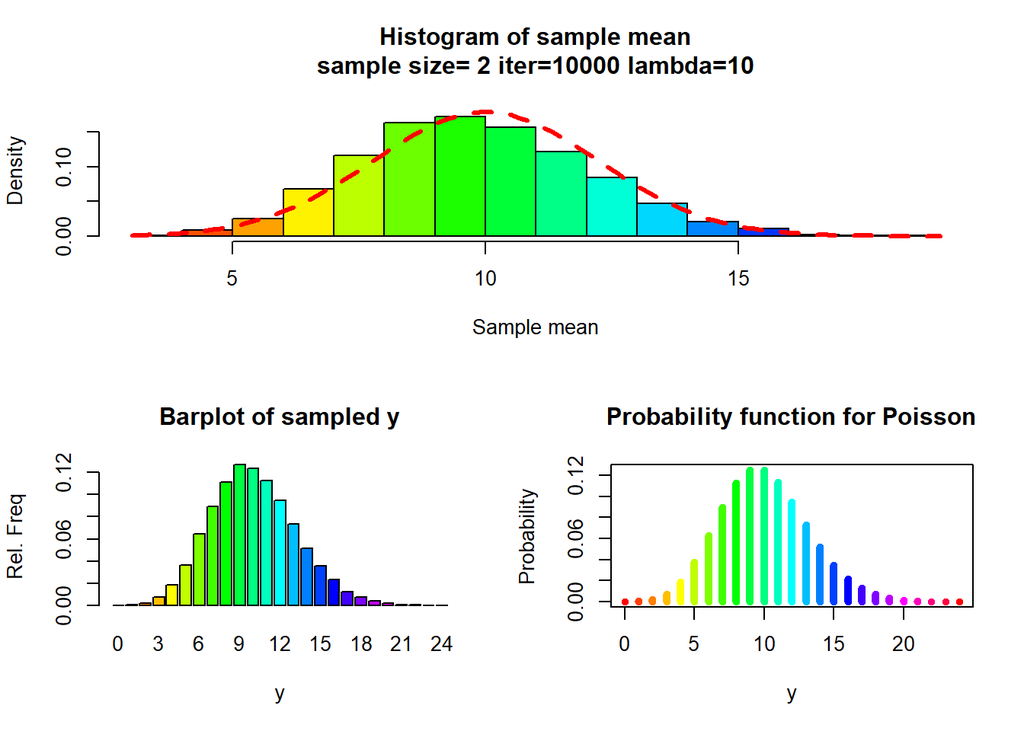

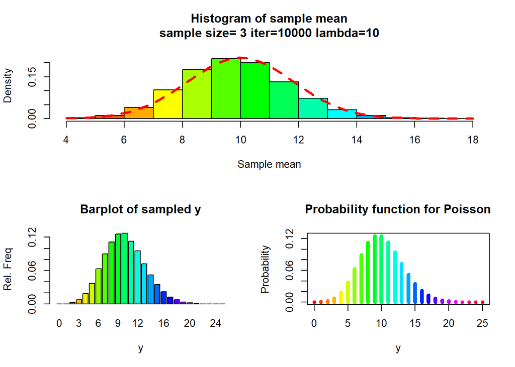

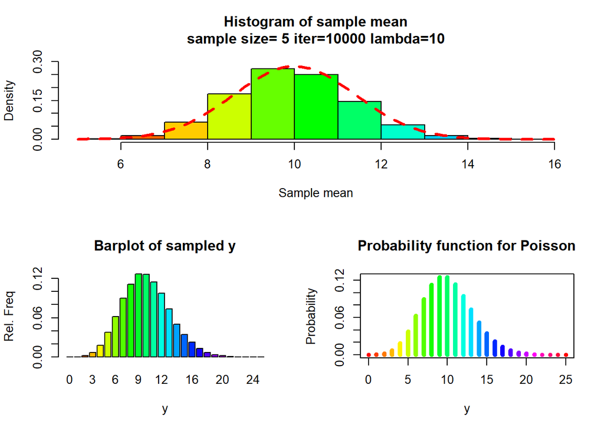

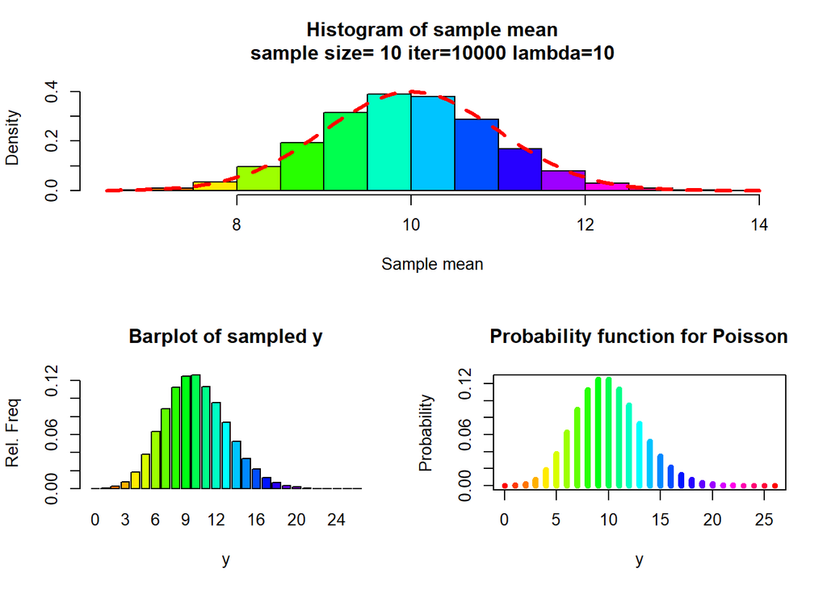

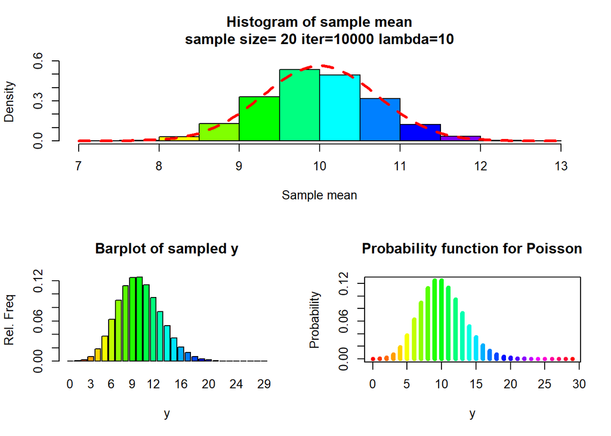

# Task 6

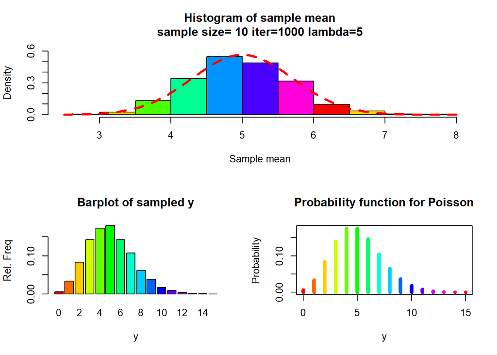

```r
library(math4753)

clt_pois(10, 1000, lambda = 5)
```